# Problem 2.1

Load the tswge library

```r
library(tswge)
```

2.1 Generate a realization of length n = 100 from the signal-plus-noise model in Problem 1.6

```r
x=gen.sigplusnoise.wge(100,b0=0,b1=0,coef=c(3,1.5),freq = c(.05,.35),psi = c(0,2))
```

[figure not shown]

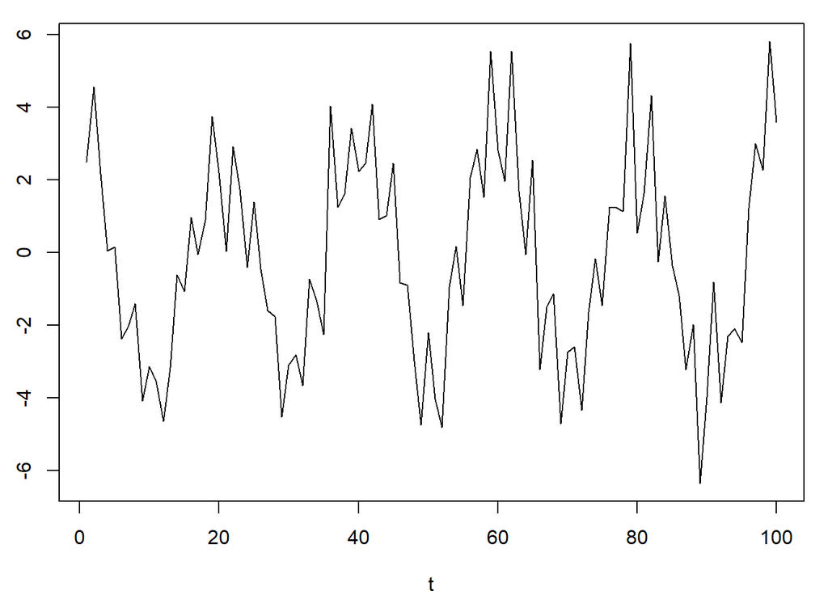

1. Apply a third-order low-pass Butterworth filter to the original realization with cutoff point 0.2.

```r
xl2=butterworth.wge(x,order=3,type = 'low',cutoff = .2)
```

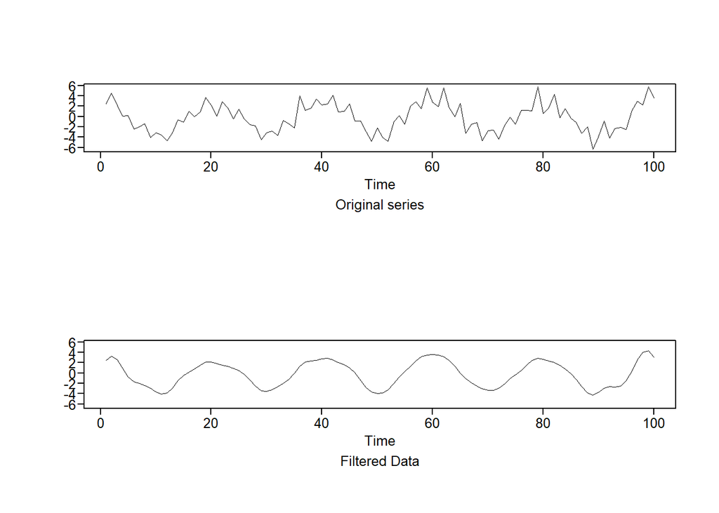

2. Apply a third-order high-pass Butterworth filter to the original realization with cutoff point 0.2.

```r
xh2=butterworth.wge(x,order=3,type = 'high',cutoff = .2)
```

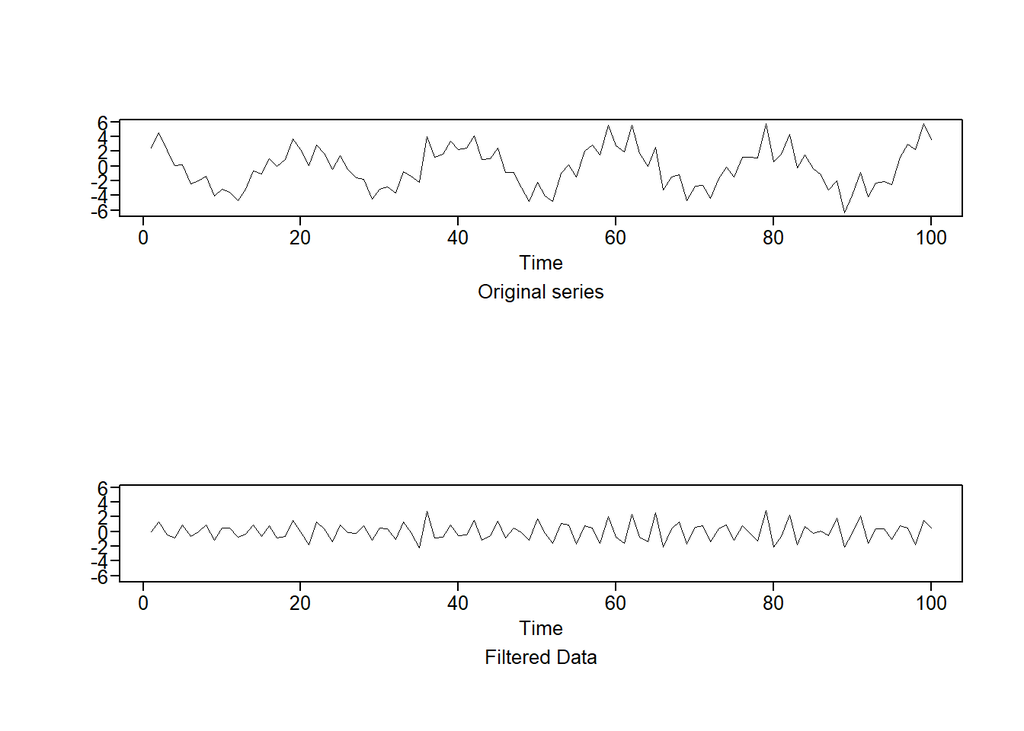

3. Apply a third-order low-pass Butterworth filter with cutoff point 0.2 to the high-pass filtered realization in (b).

```r
xhl2=butterworth.wge(xh2$x.filt,order=3,type = 'low',cutoff = .2)
```

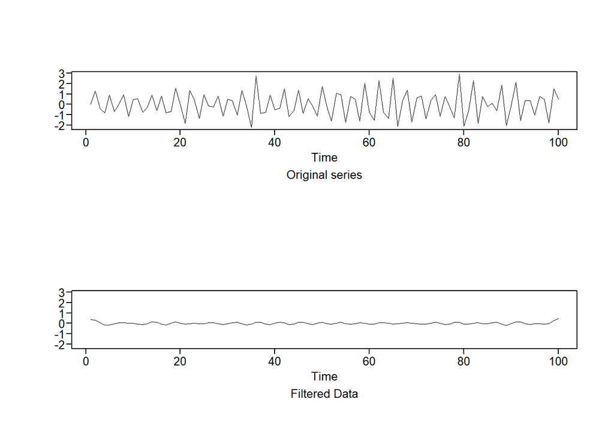

For the original data and the three filtered realizations obtained in (a-c) earlier, plot the following: i. The realization ii. The sample autocorrelations iii. The Parzen window-based spectral density estimate using the default truncation point

Discuss the cyclic behavior in the original data along with that for (a-c) and discuss the effect of the filters applied.

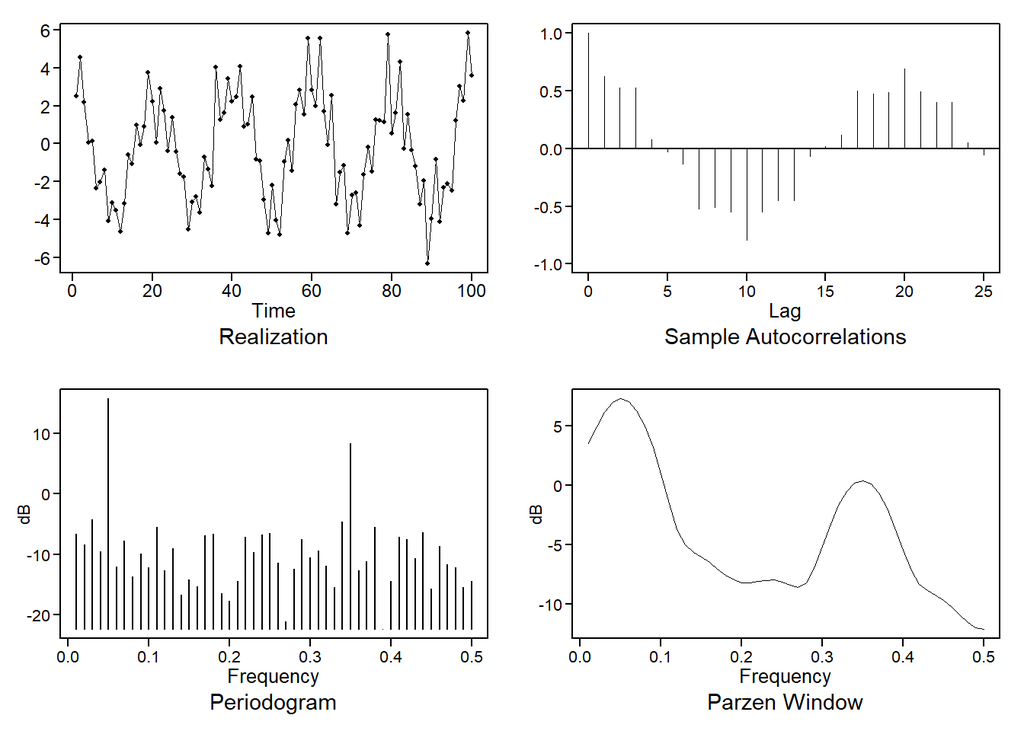

```
## $autplt
##  [1]  1.00000000  0.62800791  0.52500877  0.52485026  0.07931174
##  [6] -0.02506328 -0.12976722 -0.52530488 -0.51252169 -0.54705755
## [11] -0.79633775 -0.55032855 -0.44698261 -0.45122406 -0.06526984
## [16]  0.02182485  0.11607148  0.50287138  0.47793984  0.48676057
## [21]  0.69283645  0.49138780  0.40238355  0.39980129  0.05078956
## [26] -0.05363952
##
## $freq
##  [1] 0.01 0.02 0.03 0.04 0.05 0.06 0.07 0.08 0.09 0.10 0.11 0.12 0.13 0.14
## [15] 0.15 0.16 0.17 0.18 0.19 0.20 0.21 0.22 0.23 0.24 0.25 0.26 0.27 0.28
## [29] 0.29 0.30 0.31 0.32 0.33 0.34 0.35 0.36 0.37 0.38 0.39 0.40 0.41 0.42
## [43] 0.43 0.44 0.45 0.46 0.47 0.48 0.49 0.50
##
## $db
```

[output cut: 21 more lines]

```r
#Original Dataset
plotts.sample.wge(x)
```

This signal is characterized by cyclic behavior (with period about 20) along with a high-frequency component. The sample autocorrelations primarily show the cyclic behavior with period about 20 but may be affected slightly by the high-frequency behavior. The Parzen window (and periodogram) show two peaks at about .05 and .35.

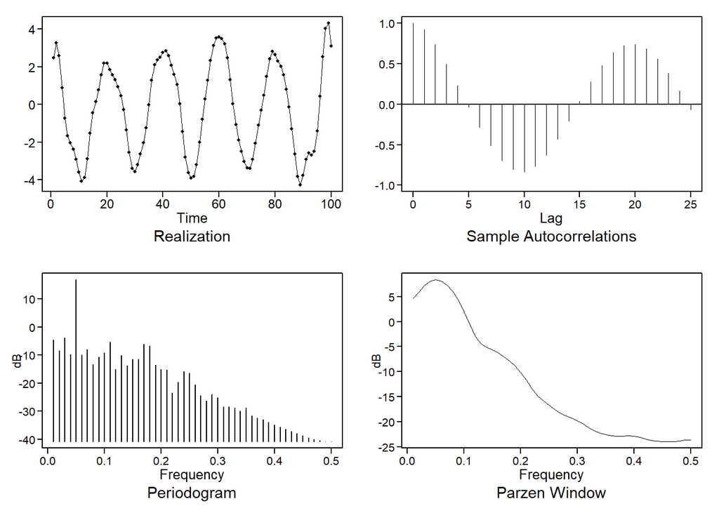

```
## $autplt
##  [1]  1.00000000  0.92543578  0.74058611  0.49474889  0.22913996
##  [6] -0.03479509 -0.28625553 -0.51256404 -0.69415593 -0.80758965
## [11] -0.83389003 -0.76868812 -0.62616158 -0.43042955 -0.20303299
## [16]  0.03904280  0.27613974  0.48319358  0.63700671  0.72417361
## [21]  0.74002333  0.68386053  0.55997682  0.38065156  0.16467099
## [26] -0.06532068
##
## $freq
##  [1] 0.01 0.02 0.03 0.04 0.05 0.06 0.07 0.08 0.09 0.10 0.11 0.12 0.13 0.14
## [15] 0.15 0.16 0.17 0.18 0.19 0.20 0.21 0.22 0.23 0.24 0.25 0.26 0.27 0.28
## [29] 0.29 0.30 0.31 0.32 0.33 0.34 0.35 0.36 0.37 0.38 0.39 0.40 0.41 0.42
## [43] 0.43 0.44 0.45 0.46 0.47 0.48 0.49 0.50
##
## $db
```

[output cut: 21 more lines]

```r
#Low-pass filter
plotts.sample.wge(xl2$x.filt)
```

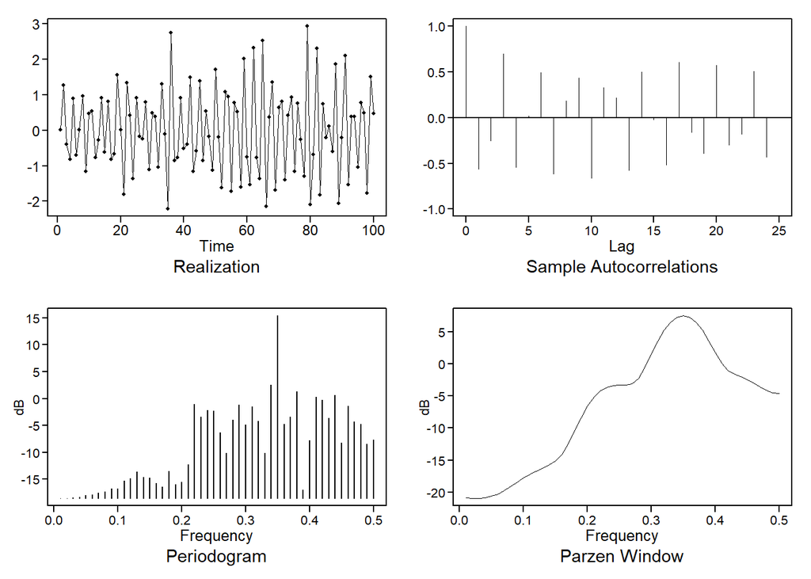

```
## $autplt
##  [1]  1.000000000 -0.562288434 -0.254239202  0.696848057 -0.540454137
##  [6]  0.018942545  0.493963194 -0.612413975  0.182861758  0.437194245
## [11] -0.664223014  0.330941428  0.219525195 -0.574264151  0.504330150
## [16] -0.023304362 -0.513380352  0.608441753 -0.161359866 -0.390581121
## [21]  0.570847164 -0.295860199 -0.181590999  0.506293305 -0.428036228
## [26] -0.003948037
##
## $freq
##  [1] 0.01 0.02 0.03 0.04 0.05 0.06 0.07 0.08 0.09 0.10 0.11 0.12 0.13 0.14
## [15] 0.15 0.16 0.17 0.18 0.19 0.20 0.21 0.22 0.23 0.24 0.25 0.26 0.27 0.28
## [29] 0.29 0.30 0.31 0.32 0.33 0.34 0.35 0.36 0.37 0.38 0.39 0.40 0.41 0.42
## [43] 0.43 0.44 0.45 0.46 0.47 0.48 0.49 0.50
##
## $db
```

[output cut: 22 more lines]

```r
#high-pass filter
plotts.sample.wge(xh2$x.filt)
```

This signal is characterized by a high-frequency (nearly up-and-down) behavior. The sample autocorrelations clearly show the cyclic behavior with period about 3. The Parzen window (and periodogram) show a peak at about .35.

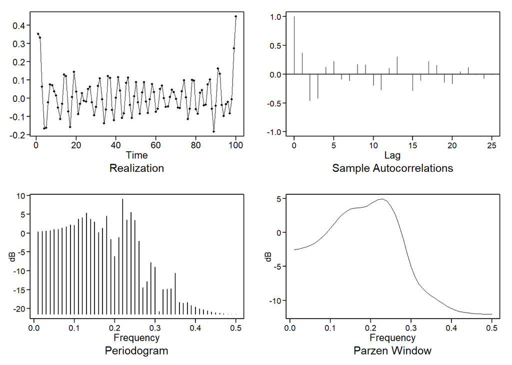

```
## $autplt
##  [1]  1.000000000  0.369799419 -0.453923497 -0.414308446  0.123971356
##  [6]  0.223198924 -0.085752243 -0.113658188  0.172606855  0.166419837
## [11] -0.192020080 -0.269604122  0.102065165  0.305255756  0.008698971
## [16] -0.284807942 -0.103239323  0.223499322  0.158246192 -0.140755547
## [21] -0.168990216  0.048042071  0.120209527 -0.004385384 -0.073639258
## [26] -0.007716353
##
## $freq
##  [1] 0.01 0.02 0.03 0.04 0.05 0.06 0.07 0.08 0.09 0.10 0.11 0.12 0.13 0.14
## [15] 0.15 0.16 0.17 0.18 0.19 0.20 0.21 0.22 0.23 0.24 0.25 0.26 0.27 0.28
## [29] 0.29 0.30 0.31 0.32 0.33 0.34 0.35 0.36 0.37 0.38 0.39 0.40 0.41 0.42
## [43] 0.43 0.44 0.45 0.46 0.47 0.48 0.49 0.50
##
## $db
```

[output cut: 22 more lines]

```r
#low-pass filtering the high-pass data
plotts.sample.wge(xhl2$x.filt)
```

###Additional Problem Apply a 5-point moving average to the series you created in 2.1. How does it compare to the difference and Butterworth filters? Specifically, is it a low pass or high pass filter?

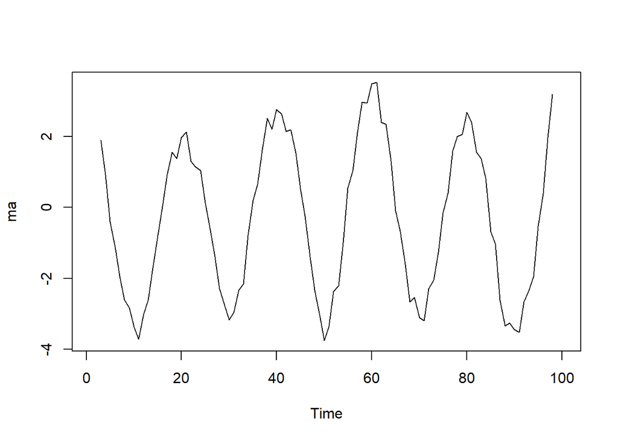

```r
#Apply a 5-point moving average to the series you created in 2.1
ma = filter(x,rep(1/5,5))
plot(ma)
```

The 5 point moving average filter is a low pass filter, the effects of which can be viewed above. While there is still possibly some remnants of the higher frequency, it is the low frequency that dominates the filtered realization. It is most comparable to a Butterworth low pass filter with cutoff of .2 although this MA filter does not appear to filter out the higher frequency as well. This is partially because the order of the Butterworth filter was set to 3.